# MPDW pertemuan 6 7

Valent Trityo Gratia Widyatmoko M0401241074

2026-09-30

```r
library(ggplot2)
library(tsibble)
library(tseries)
library(MASS)
library(forecast)
library(TSA)
library(TTR)
library(aTSA)
library(graphics)
```

# Eksplorasi Data

Data yang digunakan adalah 100 observasi awal dari dataset Suhu Minimum Harian. Data dibagi menjadi data latih dan data uji dengan proporsi 80:20.

```r
path_file <- "C:/Valent/Kuliah/Semester 5/Metode Peramalan Deret Waktu/daily-min-temperatures(1).csv"
data_suhu <- read.csv(path_file, sep="\t")

head(data_suhu)
```

```
##         Date Temp
## 1 01/01/1989 14.3
## 2 02/01/1989 17.4
## 3 03/01/1989 18.5
## 4 04/01/1989 16.8
## 5 05/01/1989 11.5
## 6 06/01/1989  9.5
```

```r
data_100 <- data_suhu[1:100, ]
data.ts <- ts(data_100$Temp)

suhu.train <- data_100$Temp[1:80]
suhu.test <- data_100$Temp[81:100]

train.ts <- ts(suhu.train, start = 1)
test.ts <- ts(suhu.test, start = 81)
```

## Plot Data Penuh

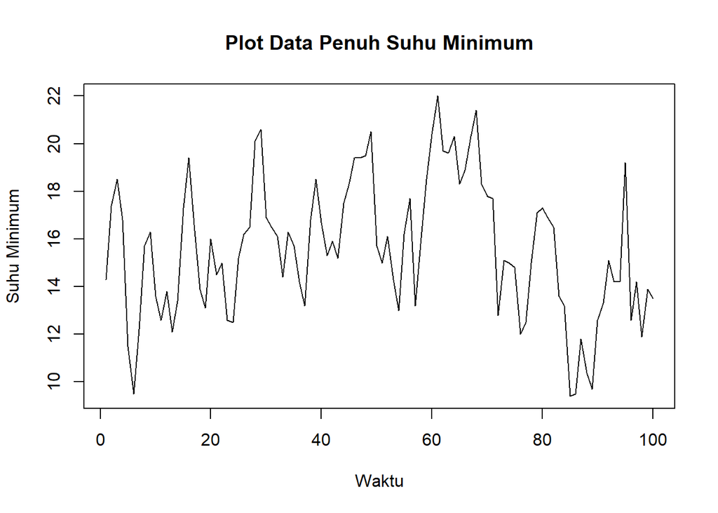

```r
plot.ts(data.ts,
        lty = 1,
        xlab = "Waktu",
        ylab = "Suhu Minimum",
        main = "Plot Data Penuh Suhu Minimum")
```

## PLot Data Latih

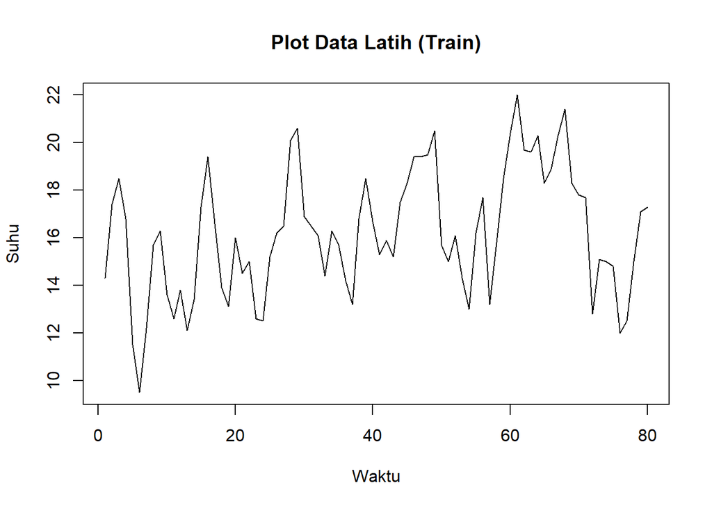

```r
plot.ts(train.ts, lty=1, xlab="Waktu", ylab="Suhu", main="Plot Data Latih (Train)")
```

Berdasarkan plot data deret waktu, data latih tampak berfluktuasi di sekitar nilai tengah yang stabil dan tidak menunjukkan adanya tren yang kuat, sehingga mengindikasikan bahwa data cenderung sudah stasioner.

## Plot data uji

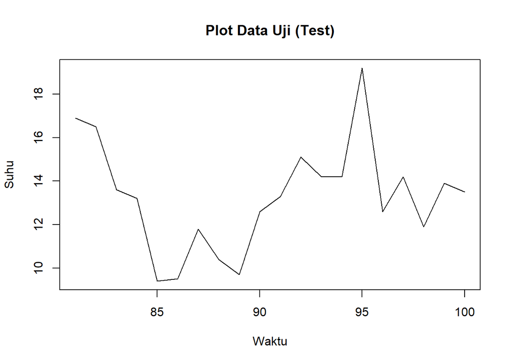

```r
plot.ts(test.ts, lty=1, xlab="Waktu", ylab="Suhu", main="Plot Data Uji (Test)")
```

# Uji Stasioneritas Data

## Plot ACF

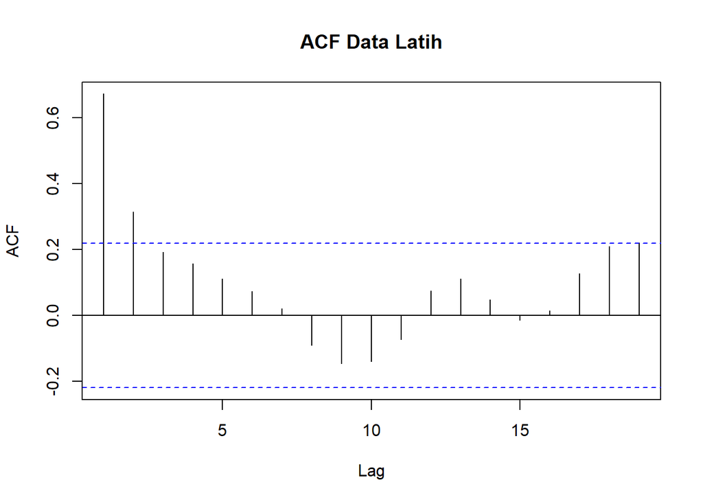

```r
acf(train.ts, main="ACF Data Latih")
```

Berdasarkan plot ACF, garis meluruh secara perlahan (tails off) atau cuts off setelah lag ke-2. Hal ini memberikan dugaan awal mengenai kestasioneran.

## Uji ADF

```r
tseries::adf.test(train.ts)
```

```
##
##  Augmented Dickey-Fuller Test
##
## data:  train.ts
## Dickey-Fuller = -3.1487, Lag order = 4, p-value = 0.1057
## alternative hypothesis: stationary
```

H0 : Data tidak stasioner dalam rataan H1 : Data stasioner dalam rataan Berdasarkan uji ADF, didapat p-value sebesar 0.1057 yang lebih besar dari taraf nyata 5% (α = 0.05) sehingga kita gagal tolak H0. Secara statistik murni, data belum stasioner kuat pada taraf 5%. Namun, karena nilainya cukup mendekati 0.1 (taraf 10%) dan plot ACF maupun data rentang waktu secara visual tampak cukup stasioner, kita akan mengasumsikan data sudah cukup stasioner dan mencoba melanjutkan pemodelan tanpa melakukan differencing (d = 0).

## Plot Box-Cox

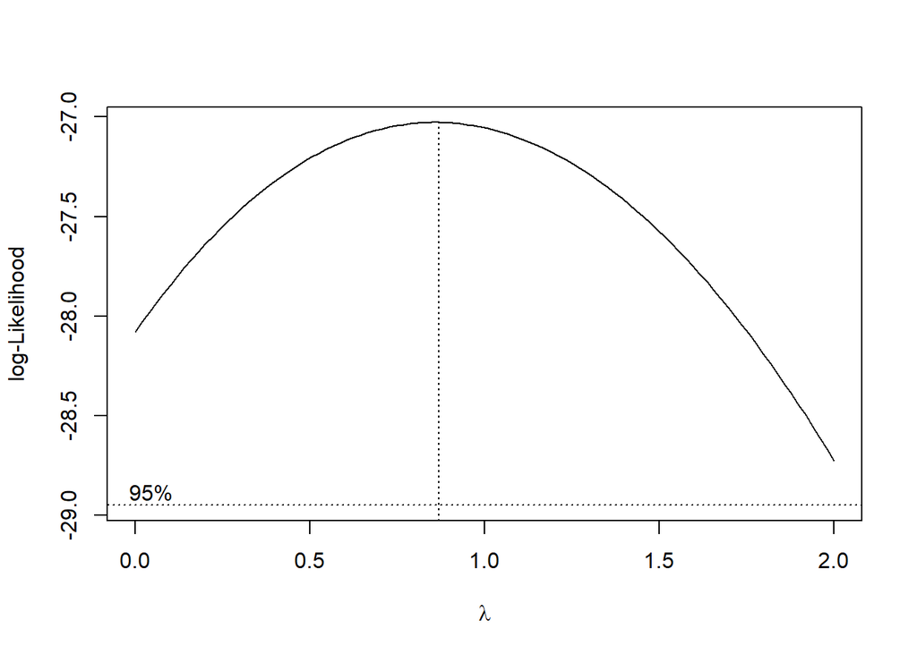

```r
index <- seq(1:length(train.ts))

min_val <- min(train.ts)
if (min_val <= 0) {
  train_shifted <- train.ts + abs(min_val) + 1
} else {
  train_shifted <- train.ts
}

bc <- boxcox(train_shifted ~ index, lambda = seq(0, 2, by = 0.1))
```

```r
lambda_opt <- bc$x[which.max(bc$y)]
lambda_opt
```

```
## [1] 0.8686869
```

```r
ci_lambda <- bc$x[bc$y > max(bc$y) - 0.5 * qchisq(0.95, df = 1)]
c(Batas_Bawah = min(ci_lambda), Batas_Atas = max(ci_lambda))
```

```
## Batas_Bawah  Batas_Atas
##           0           2
```

Selang kepercayaan untuk nilai λ memuat angka 1. Hal ini menunjukkan bahwa data sudah stasioner dalam ragam, sehingga transformasi tidak diperlukan.

# Identifikasi Model

## Plot PACF

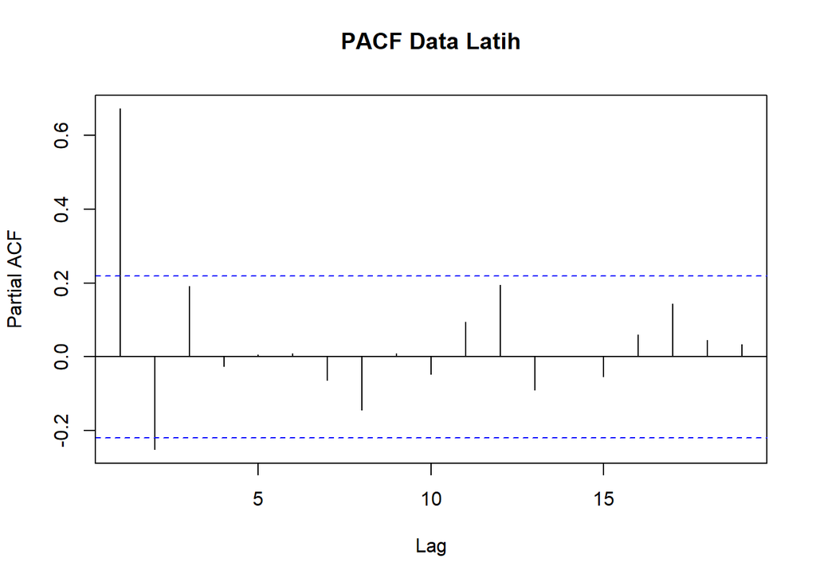

```r
pacf(train.ts, main="PACF Data Latih")
```

Berdasarkan plot PACF, terlihat cuts off pada lag pertama atau kedua. Dikombinasikan dengan ACF, kita dapat menduga beberapa model tentatif seperti ARIMA(1,0,0), ARIMA(2,0,0), ARIMA(0,0,2), dan ARIMA(1,0,1).

## Plot EACF

```r
eacf(train.ts)
```

```
## AR/MA
##   0 1 2 3 4 5 6 7 8 9 10 11 12 13
## 0 x x o o o o o o o o o  o  o  o
## 1 x o o o o o o o o o o  o  o  o
## 2 x x o o o o o o o o o  o  o  o
## 3 o o o o o o o o o o o  o  o  o
## 4 x o o o o o o o o o o  o  o  o
## 5 x o o o o o o o o o o  o  o  o
## 6 o o o o o o o o o o o  o  o  o
## 7 x o o o x o o o o o o  o  o  o
```

Berdasarkan output EACF, ujung kiri atas dari pola segitiga nol (dilambangkan dengan ‘o’) berada pada baris AR = 1 dan kolom MA = 1. Hal ini mendukung bahwa model ARIMA(1,0,1) merupakan salah satu kandidat model tentatif yang sangat kuat.

## Pendugaan Parameter Model Tentatif

```r
# ARIMA(1,0,0)
model1 <- Arima(train.ts, order=c(1,0,0), method="ML")
summary(model1)
```

```
## Series: train.ts
## ARIMA(1,0,0) with non-zero mean
##
## Coefficients:
##          ar1     mean
##       0.6690  16.1724
## s.e.  0.0816   0.6427
##
## sigma^2 = 3.9:  log likelihood = -167.24
## AIC=340.49   AICc=340.8   BIC=347.63
##
## Training set error measures:
##                     ME     RMSE      MAE       MPE     MAPE      MASE      ACF1
## Training set 0.0216666 1.950123 1.640589 -1.465405 10.64813 0.9446543 0.1767332
```

```r
lmtest::coeftest(model1)
```

```
##
## z test of coefficients:
##
##            Estimate Std. Error z value  Pr(>|z|)
## ar1        0.669012   0.081551  8.2036 2.332e-16 ***
## intercept 16.172434   0.642721 25.1624 < 2.2e-16 ***
## ---
## Signif. codes:  0 '***' 0.001 '**' 0.01 '*' 0.05 '.' 0.1 ' ' 1
```

```r
# ARIMA(0,0,2)
model2 <- Arima(train.ts, order=c(0,0,2), method="ML")
summary(model2)
```

```
## Series: train.ts
## ARIMA(0,0,2) with non-zero mean
##
## Coefficients:
##          ma1     ma2     mean
##       0.8904  0.2990  16.1682
## s.e.  0.1014  0.1081   0.4521
##
## sigma^2 = 3.605:  log likelihood = -163.69
## AIC=335.37   AICc=335.91   BIC=344.9
##
## Training set error measures:
##                      ME     RMSE      MAE       MPE     MAPE      MASE
## Training set 0.01508188 1.862671 1.532617 -1.413671 9.925872 0.8824835
##                    ACF1
## Training set 0.02978128
```

```r
lmtest::coeftest(model2)
```

```
##
## z test of coefficients:
##
##           Estimate Std. Error z value  Pr(>|z|)
## ma1        0.89038    0.10141  8.7800 < 2.2e-16 ***
## ma2        0.29903    0.10806  2.7673  0.005652 **
## intercept 16.16817    0.45214 35.7593 < 2.2e-16 ***
## ---
## Signif. codes:  0 '***' 0.001 '**' 0.01 '*' 0.05 '.' 0.1 ' ' 1
```

```r
# ARIMA(1,0,1)
model3 <- Arima(train.ts, order=c(1,0,1), method="ML")
summary(model3)
```

```
## Series: train.ts
## ARIMA(1,0,1) with non-zero mean
##
## Coefficients:
##          ar1     ma1     mean
##       0.4354  0.4779  16.1612
## s.e.  0.1319  0.1302   0.5336
##
## sigma^2 = 3.548:  log likelihood = -163.07
## AIC=334.14   AICc=334.67   BIC=343.66
##
## Training set error measures:
##                     ME     RMSE      MAE       MPE    MAPE      MASE
## Training set 0.0187698 1.848016 1.516347 -1.304418 9.81847 0.8731152
##                      ACF1
## Training set -0.004513213
```

```r
lmtest::coeftest(model3)
```

```
##
## z test of coefficients:
##
##           Estimate Std. Error z value  Pr(>|z|)
## ar1        0.43537    0.13190  3.3008 0.0009640 ***
## ma1        0.47788    0.13021  3.6700 0.0002425 ***
## intercept 16.16123    0.53361 30.2865 < 2.2e-16 ***
## ---
## Signif. codes:  0 '***' 0.001 '**' 0.01 '*' 0.05 '.' 0.1 ' ' 1
```

```r
# ARIMA(2,0,0)
model4 <- Arima(train.ts, order=c(2,0,0), method="ML")
summary(model4)
```

```
## Series: train.ts
## ARIMA(2,0,0) with non-zero mean
##
## Coefficients:
##          ar1      ar2     mean
##       0.8505  -0.2639  16.1611
## s.e.  0.1082   0.1078   0.5035
##
## sigma^2 = 3.67:  log likelihood = -164.37
## AIC=336.73   AICc=337.27   BIC=346.26
##
## Training set error measures:
##                      ME     RMSE      MAE       MPE    MAPE      MASE
## Training set 0.01916442 1.879456 1.572283 -1.344908 10.1657 0.9053236
##                    ACF1
## Training set 0.04752224
```

```r
lmtest::coeftest(model4)
```

```
##
## z test of coefficients:
##
##           Estimate Std. Error z value  Pr(>|z|)
## ar1        0.85046    0.10818  7.8615 3.796e-15 ***
## ar2       -0.26387    0.10783 -2.4472    0.0144 *
## intercept 16.16106    0.50347 32.0995 < 2.2e-16 ***
## ---
## Signif. codes:  0 '***' 0.001 '**' 0.01 '*' 0.05 '.' 0.1 ' ' 1
```

## Ringkasan AIC

```r
model_tentatif <- data.frame(
  Model = c("ARIMA(1,0,0)", "ARIMA(0,0,2)", "ARIMA(1,0,1)", "ARIMA(2,0,0)"),
  AIC   = c(AIC(model1), AIC(model2), AIC(model3), AIC(model4)),
  BIC   = c(BIC(model1), BIC(model2), BIC(model3), BIC(model4))
)

model_tentatif
```

```
##          Model      AIC      BIC
## 1 ARIMA(1,0,0) 340.4864 347.6325
## 2 ARIMA(0,0,2) 335.3738 344.9019
## 3 ARIMA(1,0,1) 334.1356 343.6637
## 4 ARIMA(2,0,0) 336.7347 346.2628
```

Model ARIMA(1,0,1) memiliki nilai AIC yang paling kecil dan seluruh parameternya signifikan. Model ini dipilih sebagai model terbaik sementara.

# Analisis Sisaan

Pengecekan asumsi sisaan (normalitas, kebebasan, kehomogenan ragam) untuk model terbaik ARIMA(1,0,1).

## Eksplorasi Sisaan

```r
sisaan <- model3$residuals

par(mfrow = c(2,2))

car::qqPlot(sisaan, main="Normal Q-Q Plot")
```

```
## [1]  5 72
```

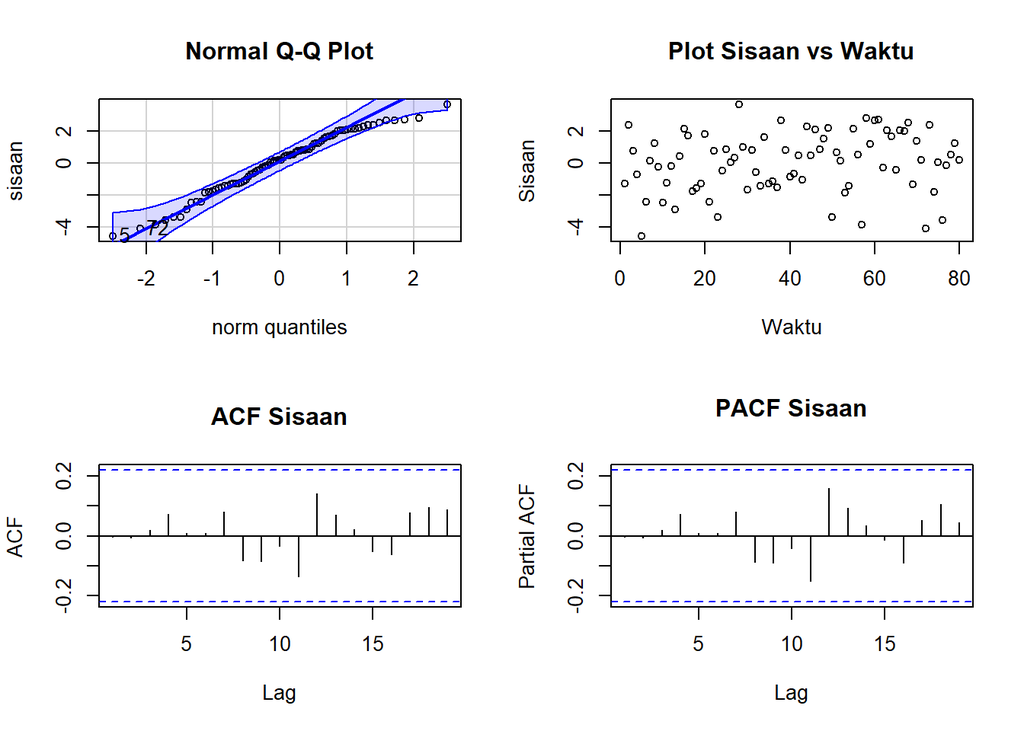

```r
plot(sisaan, type = "p", main = "Plot Sisaan vs Waktu", xlab = "Waktu", ylab = "Sisaan")

acf(sisaan, main = "ACF Sisaan")
pacf(sisaan, main = "PACF Sisaan")
```

```r
par(mfrow = c(1,1))
```

## Uji Formal

```r
# Normalitas
ks.test(sisaan, "pnorm", mean(sisaan), sd(sisaan))
```

```
##
##  Exact one-sample Kolmogorov-Smirnov test
##
## data:  sisaan
## D = 0.062712, p-value = 0.8918
## alternative hypothesis: two-sided
```

```r
# H0: Menyebar normal

# Kebebasan Sisaan
Box.test(sisaan, type = "Ljung")
```

```
##
##  Box-Ljung test
##
## data:  sisaan
## X-squared = 0.0016914, df = 1, p-value = 0.9672
```

```r
# H0: Sisaan saling bebas (tidak ada autokorelasi)

# Kehomogenan Ragam
Box.test(sisaan^2, type = "Ljung")
```

```
##
##  Box-Ljung test
##
## data:  sisaan^2
## X-squared = 1.1854, df = 1, p-value = 0.2763
```

```r
# H0: Ragam sisaan homogen

# Nilai Tengah = 0
t.test(sisaan, mu = 0, conf.level = 0.95)
```

```
##
##  One Sample t-test
##
## data:  sisaan
## t = 0.09028, df = 79, p-value = 0.9283
## alternative hypothesis: true mean is not equal to 0
## 95 percent confidence interval:
##  -0.3950593  0.4325989
## sample estimates:
## mean of x
## 0.0187698
```

```r
# H0: Nilai tengah sisaan sama dengan nol
```

Berdasarkan pengujian formal di atas, seluruh asumsi model terpenuhi dengan baik:

Normalitas: Uji KS menghasilkan p-value = 0.8918 > 0.05, gagal tolak H0 (Sisaan menyebar normal).

Kebebasan Sisaan: Uji Ljung-Box menghasilkan p-value = 0.9672 > 0.05, gagal tolak H0 (Sisaan saling bebas / tidak ada autokorelasi).

Kehomogenan Ragam: Uji Ljung-Box untuk sisaan kuadrat menghasilkan p-value = 0.2763 > 0.05, gagal tolak H0 (Ragam sisaan homogen).

Nilai Tengah Sisaan: Uji-t menghasilkan p-value = 0.9283 > 0.05, gagal tolak H0 (Nilai tengah sisaan sama dengan nol).

## Overfitting

Menaikkan orde AR dan MA dari model terbaik ARIMA(1,0,1) untuk memastikan tidak ada model yang lebih baik. Kandidat: ARIMA(2,0,1) dan ARIMA(1,0,2).

```r
# ARIMA(2,0,1)
model_over1 <- Arima(train.ts, order=c(2,0,1), method="ML")
lmtest::coeftest(model_over1)
```

```
##
## z test of coefficients:
##
##            Estimate Std. Error z value Pr(>|z|)
## ar1        0.408250   0.274122  1.4893  0.13641
## ar2        0.024597   0.219556  0.1120  0.91080
## ma1        0.502107   0.248332  2.0219  0.04318 *
## intercept 16.161119   0.539607 29.9498  < 2e-16 ***
## ---
## Signif. codes:  0 '***' 0.001 '**' 0.01 '*' 0.05 '.' 0.1 ' ' 1
```

```r
# ARIMA(1,0,2)
model_over2 <- Arima(train.ts, order=c(1,0,2), method="ML")
lmtest::coeftest(model_over2)
```

```
##
## z test of coefficients:
##
##            Estimate Std. Error z value Pr(>|z|)
## ar1        0.494384   0.379499  1.3027   0.1927
## ma1        0.412598   0.421679  0.9785   0.3278
## ma2       -0.054387   0.338087 -0.1609   0.8722
## intercept 16.161214   0.546851 29.5532   <2e-16 ***
## ---
## Signif. codes:  0 '***' 0.001 '**' 0.01 '*' 0.05 '.' 0.1 ' ' 1
```

Berdasarkan output pengujian overfitting:

Pada model ARIMA(2,0,1), parameter tambahan ar2 memiliki p-value sebesar 0.91080 > 0.05 (Tidak signifikan).

Pada model ARIMA(1,0,2), parameter tambahan ma2 memiliki p-value sebesar 0.8722 > 0.05 (Tidak signifikan). Karena parameter tambahan pada model-model overfitting tidak ada yang signifikan, maka model dasar ARIMA(1,0,1) tetap dipertahankan sebagai model terbaik.

## MOdel Terbaik

```r
model_terbaik <- model3
summary(model_terbaik)
```

```
## Series: train.ts
## ARIMA(1,0,1) with non-zero mean
##
## Coefficients:
##          ar1     ma1     mean
##       0.4354  0.4779  16.1612
## s.e.  0.1319  0.1302   0.5336
##
## sigma^2 = 3.548:  log likelihood = -163.07
## AIC=334.14   AICc=334.67   BIC=343.66
##
## Training set error measures:
##                     ME     RMSE      MAE       MPE    MAPE      MASE
## Training set 0.0187698 1.848016 1.516347 -1.304418 9.81847 0.8731152
##                      ACF1
## Training set -0.004513213
```

## Peramalan

Melakukan peramalan untuk 20 periode ke depan (sesuai panjang data uji/test). Karena kita tidak melakukan differencing (d=0), kita tidak perlu menggunakan metode inverse differencing.

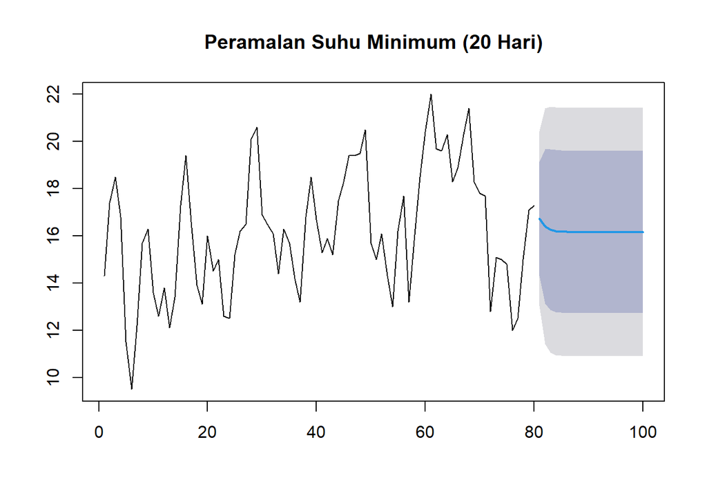

```r
ramalan <- forecast::forecast(model_terbaik, h = length(test.ts))
data.ramalan <- ramalan$mean
plot(ramalan, main="Peramalan Suhu Minimum (20 Hari)")
```

```r
perbandingan <- cbind(
  Aktual   = test.ts,
  Forecast = data.ramalan
)
print(head(perbandingan, 10))
```

```
## Time Series:
## Start = 81
## End = 90
## Frequency = 1
##    Aktual Forecast
## 81   16.9 16.73057
## 82   16.5 16.40910
## 83   13.6 16.26915
## 84   13.2 16.20822
## 85    9.4 16.18169
## 86    9.5 16.17014
## 87   11.8 16.16511
## 88   10.4 16.16292
## 89    9.7 16.16197
## 90   12.6 16.16155
```

```r
akurasi_test <- accuracy(data.ramalan, test.ts)
akurasi_test
```

```
##                 ME     RMSE     MAE       MPE     MAPE      ACF1 Theil's U
## Test set -2.926651 3.784991 3.25656 -26.23566 27.97369 0.4231548  1.871987
```

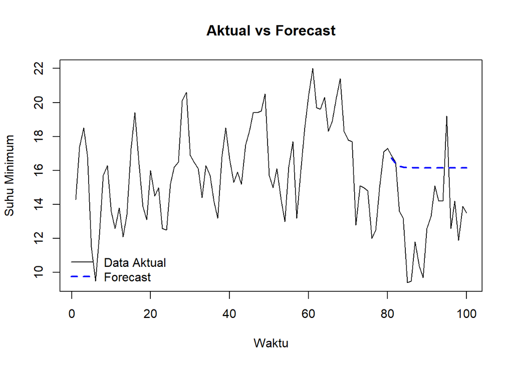

```r
# Plot gabungan Aktual dan Forecast
ts.plot(data.ts, col = "black", lty = 1,
        xlab = "Waktu", ylab = "Suhu Minimum", main = "Aktual vs Forecast")

# Tambahkan garis forecast
lines(81:(80+length(data.ramalan)), data.ramalan, col = "blue", lty = 2, lwd = 2)

legend("bottomleft",
       legend = c("Data Aktual", "Forecast"),
       col = c("black", "blue"),
       lty = c(1,2), lwd = c(1,2), bty = "n")
```

Berdasarkan tabel akurasi pada data uji (test set), didapatkan nilai MAPE sebesar 27.97%. Nilai ini menunjukkan bahwa performa peramalan model ARIMA(1,0,1) berada pada kategori yang cukup memadai dan wajar (layak) dalam memprediksi fluktuasi suhu minimum harian untuk 20 periode ke depan.